# Homework

Feihong Yu

2023-12-10

## Homework

### 模拟带漂移的随机游走

[figure not shown]

```r
## 生成时间序列数据
X <- matrix(0,1000,1)
Y <- matrix(0,1000,1)
for(i in 1:1000){

X[i+1] <- X[i]+rnorm(1)
}

for(i in 1:1000){

Y[i+1] <- Y[i]+rnorm(1)+0.3
}

plot(X,col=2,type="l")
lines(Y,col=3,type="l")
legend("topright",pch=c(15,15),legend=c("δ=0","δ=0.3"),col=c(2,3),bty="n")
```

## hw1 ### Question 利用逆变换法实现 sample 的功能

```r
my.sample <- function(x,size,replace =TRUE ,prob= NULL){
  ## 计算累计概率分布函数,记作cp
   x.size<-length(x)
   if(is.null(prob) )  cp <- c(seq(1/x.size,1,length =x.size))
    else cp<- cumsum(prob)
   ## 使用逆变换法
    u<-runif(size)
    i<- findInterval(u,cp)
    return( x[i+1])
}
## 测试集
    set.seed(2023)
    my.sample(letters,10)
```

```
##  [1] "m" "i" "e" "k" "a" "d" "l" "q" "g" "m"
```

```r
    my.sample(c(1:10),10)
```

```
##  [1]  9  2  2 10  9  2  4  9  4  8
```

### Question

The standard Laplace distribution has density
$$f(x) = (1/2) * e^{-|x|}, x \in R.$$
Use the inverse transform method to generate a random sample of size 1000 from this distribution. Use one of the methods shown in this chapter to compare the generated sample to the target distribution.

```r
#定义抽样数
N<- 1000
#抽样
U<- runif(N)
library(VGAM)
```

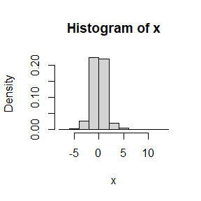

```r
x<-qlaplace(U)


# 结果包括积分上限的估计值
hist(x,probability= TRUE )
```

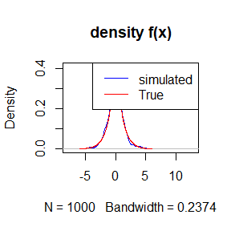

```r
plot(density(x),col= "blue",main="density f(x)")
f <- function(x) 0.5*exp(-(abs(x)))
lap.density<- f(seq(-6,6,length=N))
lines(seq(-6,6,length=N),lap.density,col= "red")
legend("topright",legend=c("simulated","True "),col=c("blue","red"),lty=c(1,1))
```

### Question Write a function to generate a random sample of size n from the Beta(a, b) distribution by the acceptance-rejection method. Generate a random sample of size 1000 from the Beta(3,2) distribution. Graph the histogram of the sample with the theoretical Beta(3,2) density superimposed.

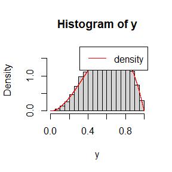

```r
n <- 1e4;j<-k<-0;y <- numeric(n)
while (k < n) {
u <- runif(1)
j <- j + 1
x <- runif(1) #random variate from g(.)
if (x^2 * (1-x) > u) {
#we accept x
k <- k + 1
y[k] <- x
}
}
hist(y,probability= TRUE )
g <- function(x)
   12*x^2*(1-x)
lap.density<- g(seq(0,1,length=n))
lines(seq(0,1,length=n),lap.density,col= "red",main="density")
legend("topright",legend=c("density"),col=c("red"),lty=c(1))
```

### Question

The [85] is a symmetric density function
$$f(x) = \frac{3}{4} \left(1 - x^2\right), \quad
|x| \leq 1$$
Devroye and Gyorfi [71, p. 236] give the following algorithm for simulation from this distribution. Generate iid U1, U2, U3 ∼ Uniform(−1, 1). If |U3| ≥ |U2| and |U3| ≥ |U1|, deliver U2; otherwise deliver U3. Write a function to generate random variates from f, and construct the histogram density estimate of a large simulated random sample.

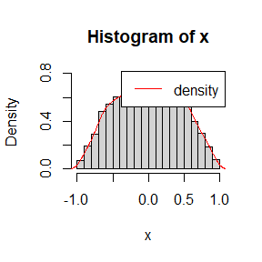

```r
N<- 30000
u<-matrix(runif(N,-1,1),nrow = N/3,ncol = 3)
x<-numeric(length = N/3)
for (i in 1:(N/3)) {
  if(abs(u[i,3])>=max(abs(u[i,]))) x[i]<- u[i,2]
  else x[i]<- u[i,3]
}
hist(x,prob= TRUE)
lines(density(x),col= "red",main="density")
legend("topright",legend=c("density"),col=c("red"),lty=c(1))
```

## hw2

### 1.Question

Proof that what value $\rho = \dfrac{l}{d}$ should take to minimize the asymptotic variance of $\hat{\pi}$?($m ∼ B(n, p)$,using $\delta$ method)

- Part 2 Simulation

```r
## \rho =1
set.seed(1006)
pihat1<- numeric(100)
pihat2<- numeric(100)
pihat3<- numeric(100)
rho <- 1
d <- 1
N <- 1e6
for (i in 1:100) {

X <- runif(N,0,d/2)
Y <- runif(N,0,pi/2)
pihat1[i] <- 2*rho/mean(1/2*sin(Y)>X)
}
rho <- 0.5
for (i in 1:100) {
X <- runif(N,0,d/2)
Y <- runif(N,0,pi/2)
pihat2[i] <- 2*rho/mean(1/2*sin(Y)>X)
}
rho <- 0.25
for (i in 1:100) {
X <- runif(N,0,d/2)
Y <- runif(N,0,pi/2)
pihat3[i] <- 2*rho/mean(1/2*sin(Y)>X)
}
## output the variance respectively，rho 1,0.5,0.25.
var(pihat1)
```

```
## [1] 5.991077e-06
```

```r
var(pihat2)
```

```
## [1] 1.27764e-06
```

```r
var(pihat3)
```

```
## [1] 2.918095e-07
```

### 2.Question

5.6 In Example 5.7 the control variate approach was illustrated for Monte Carlo integration of
$$\theta=\int_0^1 e^x d x .$$
Now consider the antithetic variate approach. Compute $\operatorname{Cov}\left(e^U, e^{1-U}\right)$ and $\operatorname{Var}\left(e^U+e^{1-U}\right)$, where $U \sim \operatorname{Uniform}(0,1)$. What is the percent reduction in variance of $\hat{\theta}$ that can be achieved using antithetic variates (compared with simple MC)?

5.7 Refer to Exercise 5.6. Use a Monte Carlo simulation to estimate $\theta$ by the antithetic variate approach and by the simple Monte Carlo method. Compute an empirical estimate of the percent reduction in variance using the antithetic variate. Compare the result with the theoretical value from Exercise 5.6.

Sol: - Part one:$Cov(e^U,e^{1-U}=\int_0^1 e^{x(1-x)} dx - (e-1)^2 =-1.7679$,and $Var(e^U+e^{1-U})=2Var(e^U)+2Cov(e^U,e^{1-U})=2.8533,Var(e^U)= 3.1945$ ,so the percent reduction is (3.1945-2.8533/2)/3.1945=55.34%.

- Part two: Simulation

```r
N <- 1e6

thetamc<- numeric(100)
thetaant <- numeric(100)
  set.seed(1006)
for ( i  in 1:100) {
  u<- runif(N)
  v<- u[1:(N/2)]
  thetamc[i]<-1/N*mean(exp(u))
  thetaant[i]<- 2/N * mean(exp(v)+exp(1-v))
}
 1-var(thetaant)/var(thetamc)
```

```
## [1] 0.5779708
```

The outcome is approximate to the theoretic result.

## hw3

### Question

(5.13) Find two importance functions f1 and f2 that are supported on (1, ∞) and are ‘close’ to $g(x) = \frac{x^2}{\sqrt{2\pi}}e^{−x^2/2}, x > 1$. Which of your two importance functions should produce the smaller variance in estimating $\int_1^\infty \frac{x^2}{\sqrt{2\pi}}e^{−x^2/2}dx$ by importance sampling? Explain.?

[figure not shown]

```r
set.seed(20231015)
g <- function(x){
  x^2*exp(-x^2/2)/sqrt(2*pi)*(x>=1)
}
x = seq(1,8,0.01)
gs <- c(expression(g(x)),expression(f1(x)),expression(f2(x)))
par(mfrow=c(1,2))
# figure of g, f1, f2
plot(x, g(x), type="l", ylab="", ylim=c(0,0.7), lwd = 1, col=1)
lines(x, dnorm(x), lwd=1, col=2)
lines(x, dgamma(x,3,2), lwd=1, col=3)
legend("topright", legend = gs, lty=1, lwd=1, inset = 0.02,col=1:3)

# figure of g/f1, g/f2
plot(x, g(x)/dnorm(x), type="l", ylab="", ylim=c(0,5), lwd = 1, col=2)
lines(x, g(x)/dgamma(x,3,2), lwd=1, col=3)
legend("topright", legend = gs[-1], lty=1, lwd=1, inset = 0.02,col=2:3)
```

Now, let’s proceed with a simulation:

```r
set.seed(20231015)
m = 1e4
theta <- se <- numeric(2)
# using f1
x <- rnorm(m)
fg <- g(x) / dnorm(x)
theta[1] <- mean(fg)
se[1] <- sd(fg)
# using f2
x <- rgamma(m,3,2)
fg <- g(x) / dgamma(x,3,2)
theta[2] <- mean(fg)
se[2] <- sd(fg)
rbind(theta, se)
```

```
##            [,1]      [,2]
## theta 0.4022867 0.3928710
## se    1.1202321 0.3041682
```

```r
se^2
```

```
## [1] 1.25492000 0.09251827
```

After conducting the simulation, we can affirm that $f_2$ offers a superior estimation of $\theta$

### Question

```r
alpha <- 3
beta <- 1

# Number of samples
N <- 100000

sample <- rgamma(N, shape = alpha, rate = beta)
est <- (mean((sample^2 * gamma(alpha)) / beta^alpha))

# Print the estimate
cat("Monte Carlo Estimate:", est, "\n")
```

```
## Monte Carlo Estimate: 24.07865
```

### Question

(5.15) Obtain the stratified importance sampling estimate in Example 5.13 and compare it with the result of Example 5.10. + Example 5.10

```r
set.seed(20231015)
m <- 1e6
estimation <- sd <- 0
g <- function(x){
  exp(-x - log(1+x^2)) * (x > 0) * (x < 1)
}
u <- runif(m) #f3, inverse transform method
x <- - log(1 - u * (1 - exp(-1)))
fg <- g(x) / (exp(-x) / (1 - exp(-1)))
estimation <- mean(fg)
sd <- sd(fg)
```

- Example 5.13

Let $f(x)=\frac{e^{-x}}{1-e^{-1}}$, $F(x)=\int f(x)=\frac{1-e^{-x}}{1-e^{-1}}$. Then $F^{-1}(x)=-log[1-(1-e^{-1})x)]$. We divide the real line into $k=5$ intervals $I_j=\{x:a_{j-1}\leq x<a_j\}$ and $a_j=F^{-1}(\frac{j}{k}),j=1,\dots,k$. On each subinterval, the conditional density $f_j$ of $X$ is
$$f_j(x)=f_{X|I_j}(x|I_j)=\frac{f(x,a_{j-1}\leq
x<a_j)}{P(a_{j-1}\leq x<a_j)}=kf(x),\quad a_{j-1}\leq
x<a_j.$$

```r
M <- 10000
k <- 5
m <- M/k # replicates per stratum
T1 <- T2 <- numeric(k)
estimation_2 <- numeric(2)
fj <- function(x)5*exp(-x)/(1-exp(-1)) # fj(x)
g <- function(x)exp(-x)/(1+x^2)
```

For each subinterval $I_j$, we use inverse transform method to generate samples from $f_j(x)$. Since
$$\begin{aligned}
F_j(x)
&=\int_{a_{j-1}}^{x}f_j(x)dx\\
&=5F(x)-5F(a_{j-1})\\
&=5(F(x)-j+1),
\end{aligned}$$
we have $F^{-1}_j(x)=-log[1-(1-e^{-1})(x+j-1)]$.
Let $\sigma_j^2=Var(g_j(X)/f_j(X))$. For each $j = 1,...,k$, we simulate an importance sample size $m$, compute the importance sampling estimator $\hat\theta_j$ of $\theta_j$ on the $j^{th}$ subinterval, and compute $\displaystyle\hat\theta^{SI}=\sum_{j=1}^k{\hat\theta_j}$.Then by independence of $\hat\theta_1,..., \hat\theta_k$,
$$\displaystyle
Var(\hat\theta^{SI})=Var(\sum_{j=1}^k{\hat\theta_j})=\sum_{j=1}^k{\frac{\sigma_j^2}{m}}=\frac{1}{m}\sum_{j=1}^k{\sigma_j^2}.$$

```r
set.seed(20231015)
for(j in 1:k){
  u = runif(m)
  x = -log(1-(1-exp(-1))*(u+j-1)/5) # inverse transform method
  T1[j] = mean(g(x)/fj(x))
  T2[j] = var(g(x)/fj(x))
}
estimation_2[1] = sum(T1)
estimation_2[2] = sum(T2)
round(c(estimation,estimation_2[1]),4)
```

```
## [1] 0.5250 0.5249
```

```r
round(c(sd,sqrt(estimation_2[2])),5)
```

```
## [1] 0.09674 0.00938
```

From the results, it’s oblivious that the stratified importance sampling estimate is better because its variance is much smaller than the result of Example 5.10.

### Question

(6.5) Suppose a 95% symmetric t-interval is applied to estimate a mean, but the sample data are non-normal. Then the probability that the confidence interval covers the mean is not necessarily equal to 0.95. Use a Monte Carlo experiment to estimate the coverage probability of the t-interval for random samples of $χ^2(2)$ data with sample size n = 20. Compare your t-interval results with the simulation results in Example 6.4. (The t-interval should be more robust to departures from normality than the interval for variance.)

```r
cl <- 0.95
s <- 20
n <- 10000
true_mean <- 2

suc_intervals <- 0

for (i in 1:n) {
  x <- rchisq(s, df = 2)

  sample_mean <- mean(x)
  sample_sd <- sd(x)

  moe <- qt((1 + cl) / 2, df = s - 1) * (sample_sd / sqrt(s))
  interval <- c(sample_mean - moe, sample_mean + moe)

  if (true_mean >= interval[1] && true_mean <= interval[2]) {
    suc_intervals <- suc_intervals + 1
  }
}

c_p <- suc_intervals / n

cat("Estimated Coverage Probability:", c_p, "\n")
```

```
## Estimated Coverage Probability: 0.9175
```

The t-interval should be more robust to departures from normality than the interval for variance.

## Question

(6.A) Use Monte Carlo simulation to investigate whether the empirical Type I error rate of the t-test is approximately equal to the nominal significance level $α$, when the sampled population is non-normal. The t-test is robust to mild departures from normality. Discuss the simulation results for the cases where the sampled population is (i) $χ^2(1)$, (ii) Uniform(0,2), and (iii) Exponential(rate=1). In each case, test $H_0 : µ = µ_0 ~vs~ H_0 : µ \µ0_,$ where µ0 is the mean of $χ^2(1)$, Uniform(0,2), and Exponential(1), respectively.

```r
n <- 10000
alpha <- 0.05

true_mean_chi_sq <- 1
true_mean_uniform <- 1
true_mean_exponential <- 1

rej_chi_sq <- 0
rej_uniform <- 0
rej_exponential <- 0

# Perform Monte Carlo simulations for each case
for (i in 1:n) {

  sample_chi_sq <- rchisq(30, df = 1)
  sample_uniform <- runif(30, min = 0, max = 2)
  sample_exponential <- rexp(30, rate = 1)

  t_test_chi_sq <- t.test(sample_chi_sq, mu = true_mean_chi_sq, alternative = "two.sided")
  t_test_uniform <- t.test(sample_uniform, mu = true_mean_uniform, alternative = "two.sided")
  t_test_exponential <- t.test(sample_exponential, mu = true_mean_exponential, alternative = "two.sided")

  if (t_test_chi_sq$p.value < alpha) {
    rej_chi_sq <- rej_chi_sq + 1
  }

  if (t_test_uniform$p.value < alpha) {
    rej_uniform <- rej_uniform + 1
  }

  if (t_test_exponential$p.value < alpha) {
    rej_exponential <- rej_exponential + 1
  }
}

t1e_chi_sq <- rej_chi_sq / n
t1e_uniform <- rej_uniform / n
t1e_exponential <- rej_exponential / n

# Print the results
cat("Type I Error Rate for χ²(1) Data:", t1e_chi_sq, "\n")
```

```
## Type I Error Rate for χ²(1) Data: 0.0932
```

```r
cat("Type I Error Rate for Uniform(0,2) Data:", t1e_uniform, "\n")
```

```
## Type I Error Rate for Uniform(0,2) Data: 0.0506
```

```r
cat("Type I Error Rate for Exponential(1) Data:", t1e_exponential, "\n")
```

```
## Type I Error Rate for Exponential(1) Data: 0.0705
```

## hw4

### Question

- Suppose the population has the exponential distribution with rate $\lambda$, then the MLE of $\lambda$ is $\hat\lambda=1/\bar X$, where $\bar X$ is the sample mean. It can be derived that the expectation of $\hat\lambda$ is $\lambda n/(n-1)$, so that the estimation bias is $\lambda/(n-1)$. The standard error $\hat\lambda$ is $\lambda n/[(n-1)\sqrt{n-2}]$. Conduct a simulation study to verify the performance of the bootstrap method.
  - The true value of $\lambda=2$.
  - The sample size $n=5,10,20$.
  - The number of bootstrap replicates $B = 1000$.
  - The simulations are repeated for $m=1000$ times.
  - Compare the mean bootstrap bias and bootstrap standard error with the theoretical ones. Comment on the results.

```r
   set.seed(20231022)
    library(boot); library(MASS)
    lambda <- function(x,i) 1/mean(x[i])
    n <- 20
    x <- rexp(n,2)
    obj <- boot(data=x,statistic=lambda,R=1e4)
    round(c(original=obj$t0,bias=mean(obj$t)-obj$t0,
            se=sd(obj$t)),3)
```

```
## original     bias       se
##    1.731    0.066    0.348
```

Theoretically,the bia and se are 0.10，0.496.

n=10

```r
    n <- 10
    x <- rexp(n,2)
    obj <- boot(data=x,statistic=lambda,R=1e4)
    round(c(original=obj$t0,bias=mean(obj$t)-obj$t0,
            se=sd(obj$t)),3)
```

```
## original     bias       se
##    2.017    0.107    0.505
```

Theoretically,the bias and se are 0.22，0.786.

n=5

```r
    n <- 5
    x <- rexp(n,2)
    obj <- boot(data=x,statistic=lambda,R=1e4)
    round(c(original=obj$t0,bias=mean(obj$t)-obj$t0,
            se=sd(obj$t)),3)
```

```
## original     bias       se
##    3.202    0.839    2.593
```

Theoretically,the bia and se are 0.50，1.44.

```r
library(bootstrap)
library(boot)
law1<-as.matrix(law)

boot.t.ci <-
function(x, B = 500, R = 100, level = .95, statistic){
#compute the bootstrap t CI
x <- as.matrix(x); n <- nrow(x)
stat <- numeric(B); se <- numeric(B)
boot.se <- function(x, R, f) {
#local function to compute the bootstrap
#estimate of standard error for statistic f(x)
x <- as.matrix(x); m <- nrow(x)
th <- replicate(R, expr = {
i <- sample(1:m, size = m, replace = TRUE)
f(x[i, ])
})
return(sd(th))
}
for (b in 1:B) {
j <- sample(1:n, size = n, replace = TRUE)
y <- x[j, ]
stat[b] <- statistic(y)
se[b] <- boot.se(y, R = R, f = statistic)
}
stat0 <- statistic(x)
t.stats <- (stat - stat0) / se
se0 <- sd(stat)
alpha <- 1 - level
Qt <- quantile(t.stats, c(alpha/2, 1-alpha/2), type = 1)
names(Qt) <- rev(names(Qt))
CI <- rev(stat0 - Qt * se0)
}

b.cor <- function(x,i) cor(x[i,1],x[i,2])

ci <- boot.t.ci(law1, statistic = b.cor, B=2000, R=200)
print(ci)
```

```
##       2.5%      97.5%
## -0.2139617  0.9777151
```

## hw5

### Question

Refer to Exercise 7.4. Compute 95% bootstrap confidence intervals for the mean time between failures 1/λ by the standard normal, basic, percentile, and BCa methods. Compare the intervals and explain why they may differ.

Sol:From Ex 7.4 ,Let $\vec{X}\in \mathbb{R}^n$ be sample, we obtain the loglikelihood
$$l(\lambda|x)=\lambda^ne^{-\lambda \sum x_i}$$
Compute the maxmimizer and get $\hat{\lambda}_{MLE} = \frac{1}{\bar{X}}$ so the estimator for $\hat{\frac{1}{\lambda}}=\bar{X}$. Below we show in Rlab how to compute the confidence intervals

```r
m<- 1000
set.seed(20231028)
library(boot)
b.mean<- function(x,i) mean(x[i])
data<-as.matrix(aircondit)
ci.norm<-ci.basic<-ci.perc<-ci.bca<-matrix(NA,m,2)

  bootout<- boot(data= data,statistic = b.mean ,R =1000)
  ci <- boot.ci(bootout,type=c("norm","basic","perc","bca"))
  print(ci)
```

```
## BOOTSTRAP CONFIDENCE INTERVAL CALCULATIONS
## Based on 1000 bootstrap replicates
##
## CALL :
## boot.ci(boot.out = bootout, type = c("norm", "basic", "perc",
##     "bca"))
##
## Intervals :
## Level      Normal              Basic
## 95%   ( 35.2, 182.0 )   ( 26.9, 169.7 )
##
## Level     Percentile            BCa
## 95%   ( 46.4, 189.2 )   ( 58.8, 231.4 )
## Calculations and Intervals on Original Scale
## Some BCa intervals may be unstable
```

The intervals are different because they apply different assumptions to the bootstrap resamples.

### Question

Refer to Exercise 7.7. Obtain the jackknife estimates of bias and standard error of $\hat{\theta}$

Sol: Note that the sample covariance matrix is symmetric ,so the sum of eigenvalue equals to the trace of the matrix.

```r
library(bootstrap)
m<-nrow(scor)
Cov<-cov(scor)
theta=max(eigen(Cov)$values)/sum(diag(Cov))
thetajack<- numeric(m)
for (i in 1:m){
  cov<- cov(scor[-i,])
  sum<-sum(diag(cov))
  thetajack[i]<- max(eigen(cov)$values)/sum
}
jackmean<- mean(thetajack)
bias <- (m-1)*(jackmean-theta)
variance<- m/(m-1)* sum((thetajack-jackmean)^2)
print(c(bias,variance))
```

```
## [1] 0.001069139 0.002512202
```

### Question

In Example 7.18, leave-one-out (n-fold) cross validation was used to select the best fitting model. Use leave-two-out cross validation to compare the models.

```r
library(DAAG)
attach(ironslag)
n <- length(magnetic)
#in DAAG ironslag
e1 <- e2 <- e3 <- e4 <- matrix(0,nrow = n*(n-1),ncol=2)
# for n-fold cross validation
# fit models on leave-two-out samples
for (k in 1:(n-1)) {
  for (l in 1:(n-1)) {


y1 <- magnetic[-k]
x1 <- chemical[-k]
y <- y1[-l]
x <- x1[-l]
J1 <- lm(y ~ x)
yhat11 <- J1$coef[1] + J1$coef[2] * chemical[k]
yhat12 <- J1$coef[1] + J1$coef[2] * x1[l]
e1[(k-1)*n+l,1] <- magnetic[k] - yhat11
e1[(k-1)*n+l,2] <- y1[l] - yhat12
J2 <- lm(y ~ x + I(x^2))
yhat21 <- J2$coef[1] + J2$coef[2] * chemical[k] +
J2$coef[3] * chemical[k]^2
yhat22 <- J2$coef[1] + J2$coef[2] * x1[l] +
J2$coef[3] * x1[l]^2
e2[(k-1)*n+l,1] <- magnetic[k] - yhat21
e2[(k-1)*n+l,2] <- y1[l] - yhat22

J3 <- lm(log(y) ~ x)
logyhat31 <- J3$coef[1] + J3$coef[2] * chemical[k]
logyhat32 <- J3$coef[1] + J3$coef[2] * x1[l]
yhat31 <- exp(logyhat31)
yhat32 <- exp(logyhat32)
e3[(k-1)*n+l,1] <- magnetic[k] - yhat31
e3[(k-1)*n+l,2] <- y1[l] - yhat32

J4 <- lm(log(y) ~ log(x))
logyhat41 <- J4$coef[1] + J4$coef[2] * log(chemical[k])
logyhat42 <- J4$coef[1] + J4$coef[2] * log(x1[l])
yhat41 <- exp(logyhat41)
yhat42 <- exp(logyhat42)
e4[(k-1)*n+l,1] <- magnetic[k] - yhat41
e4[(k-1)*n+l,2] <- y1[l] - yhat42
}
}
c(mean(colMeans(e1^2)), mean(colMeans(e2^2)), mean(colMeans(e3^2)), mean(colMeans(e4^2)))
```

```
## [1] 18.63850 16.84783 17.37527 19.35757
```

According to the prediction error criterion, Model 2, the quadratic model, would be the best fit for the data.

```r
summary( lm(magnetic~ chemical+I(chemical^2)))
```

```
##
## Call:
## lm(formula = magnetic ~ chemical + I(chemical^2))
##
## Residuals:
##     Min      1Q  Median      3Q     Max
## -8.4335 -2.7006 -0.2754  2.5446 12.2665
##
## Coefficients:
##               Estimate Std. Error t value Pr(>|t|)
## (Intercept)   24.49262    9.14657   2.678   0.0100 **
## chemical      -1.39334    0.88852  -1.568   0.1232
## I(chemical^2)  0.05452    0.02081   2.620   0.0116 *
## ---
## Signif. codes:  0 '***' 0.001 '**' 0.01 '*' 0.05 '.' 0.1 ' ' 1
##
## Residual standard error: 4.098 on 50 degrees of freedom
## Multiple R-squared:  0.5931, Adjusted R-squared:  0.5768
## F-statistic: 36.44 on 2 and 50 DF,  p-value: 1.728e-10
```

## hw6

### Question

Proof the Stationarity of Metropolis-Hastings sampler Algorithm in continuous situation.

Sol:When $s=r$ the equation holds.When $s\neq r$
$$\begin{aligned}
K(r,s)f(r)= & \alpha(r,s)g(s|r)f(r)\\
=& \begin{cases}
f(r)g(s|r) & ,f(r)g(s|r)\geq f(s)g(r|s)\\
f(s)g(r|s) & ,f(r)g(s|r)< f(s)g(r|s)
\end{cases}
\end{aligned}$$
From intuition of symmetry,it can be attested that $K(s,r)f(s) $ has the same expression.

### Question

Implement the two-sample Cram´er-von Mises test for equal distributions as a permutation test. Apply the test to the data in Examples 8.1 and 8.2.

- Eg8.1

```r
library(CDFt)
attach(chickwts)
x <- sort(as.vector(weight[feed == "soybean"]))
y <- sort(as.vector(weight[feed == "linseed"]))
detach(chickwts)
R <- 999 #number of replicates
z <- c(x, y) #pooled sample
K <- 1:26
D <- numeric(R) #storage for replicates
options(warn = -1)
D0 <- CramerVonMisesTwoSamples(x, y)
for (i in 1:R) {
#generate indices k for the first sample
k <- sample(K, size = 14, replace = FALSE)
x1 <- z[k]
y1 <- z[-k] #complement of x1
D[i] <- CramerVonMisesTwoSamples(x1, y1)
}
p <- mean(c(D0, D) >= D0)
options(warn = 0)
p
```

```
## [1] 0.418
```

### Question

The Count 5 test for equal variances in Section 6.4 is based on the maximum number of extreme points. Example 6.15 shows that the Count 5 criterion is not applicable for unequal sample sizes. Implement a permutation test for equal variance based on the maximum number of extreme points that applies when sample sizes are not necessarily equal.

```r
set.seed(20231105)
count5test <- function(x, y) {
X <- x - mean(x)
Y <- y - mean(y)
outx <- sum(X > max(Y)) + sum(X < min(Y))
outy <- sum(Y > max(X)) + sum(Y < min(X))
# return 1 (reject) or 0 (do not reject H0)
return(as.integer(max(c(outx, outy)) > 5))
}
R <- 999 #number of replicates
n1 <- 20
n2 <- 30
mu1 <- mu2 <- 0
sigma1 <- sigma2 <- 1
x <- rnorm(n1, mu1, sigma1)
y <- rnorm(n2, mu2, sigma2)
X <- x - mean(x) #centered by sample mean
Y <- y - mean(y)
z<- c(X,Y)
K <- 1:50
D <- numeric(R) #storage for replicates
options(warn = -1)
D0 <- count5test(X, Y)
for (i in 1:R) {
#generate indices k for the first sample
k <- sample(K, size = 20, replace = FALSE)
x1 <- z[k]
y1 <- z[-k] #complement of x1
D[i] <- count5test(x1, y1)
}
p <- ifelse(D0 == 0, mean( c(D0, D) > D0 ), mean( c(D0, D) >= D0 ))
options(warn = 0)
p
```

```
## [1] 0.104
```

## hw7

### Question

1. Consider a model $P\left(Y=1 \mid X_1, X_2, X_3\right)=\frac{\exp \left(a+b_1 X_1+b_2 X_2+b_3 X_3\right)}{1+\exp \left(a+b_1 X_1+b_2 X_2+b_3 X_3\right)}$, where $X_1 \sim P(1), X_2 \sim \operatorname{Exp}(1)$ and $X_3 \sim B(1,0.5)$.
- Design a function that takes as input values $N, b_1, b_2, b_3$ and $f_0$, and produces the output $a$.
- Call this function, input values are $N=10^6, b_1=0, b_2=1, b_3=-1, f_0=0.1,0.01,0.001,0.0001$.
- Plot $-\log f_0$ vs $a$.

Sol

```r
set.seed(20231112)
my.root<- function (N,b1,b2,b3,f0)    {
x1 <- rpois(N,1);x2 <- rexp(N,1); x3 <- sample(0:1,N,replace=TRUE)
g <- function(alpha){
tmp <- exp(-alpha-b1*x1-b2*x2-b3*x3); p <- 1/(1+tmp)
mean(p) - f0
}
solution <- uniroot(g,c(-1000,1000))
round(unlist(solution),5)[1]   }
my.root(N=1e6,b1=0,b2=1,b3=-1,f0=0.1)
```

```
##     root
## -3.16449
```

```r
my.root(N=1e6,b1=0,b2=1,b3=-1,f0=0.01)
```

```
##     root
## -6.06838
```

```r
my.root(N=1e6,b1=0,b2=1,b3=-1,f0=0.001)
```

```
##    root
## -8.7306
```

```r
my.root(N=1e6,b1=0,b2=1,b3=-1,f0=0.0001)
```

```
##      root
## -11.26707
```

[figure not shown]

```r
f<-seq(0,1,length=100)
vecroot<- Vectorize(my.root)
a<-vecroot(N=1e6,b1=0,b2=1,b3=-1,f0=f)
plot(-log(f),a,type="l")
```

### Question 9.4

Implement a random walk Metropolis sampler for generating the standard Laplace distribution (see Exercise 3.2). For the increment, simulate from a normal distribution. Compare the chains generated when different variances are used for the proposal distribution. Also, compute the acceptance rates of each chain.

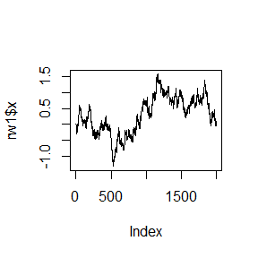

```r
set.seed(20231112)
 lapla <- function(x) 1/2*exp(-abs(x))

 rw.Metropolis <- function(sigma, x0, N) {
   x <- numeric(N)
   x[1] <- x0
   u <- runif(N)
   k <- 0
   for (i in 2:N) {
     y <- rnorm(1, x[i-1], sigma)
     if (u[i] <= (lapla(y) / lapla(x[i-1])))
       x[i] <- y else {
         x[i] <- x[i-1]
         k <- k + 1
       }
   }
   return(list(x=x, k=k/N))
 }

 N <- 2000
 sigma <- c(.05, .5,1, 2, 5,15)
 x0 <- 0
 rw1 <- rw.Metropolis(sigma[1], x0, N)
 rw2 <- rw.Metropolis(sigma[2], x0, N)
 rw3 <- rw.Metropolis(sigma[3], x0, N)
 rw4 <- rw.Metropolis(sigma[4], x0, N)
 rw5 <- rw.Metropolis(sigma[5], x0, N)
 rw6 <- rw.Metropolis(sigma[6], x0, N)
 plot(rw1$x,type="l")
```

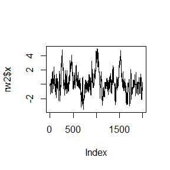

```r
 plot(rw2$x,type="l")
```

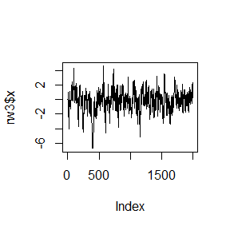

```r
 plot(rw3$x,type="l")
```

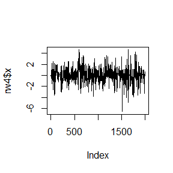

```r
 plot(rw4$x,type="l")
```

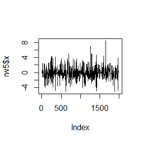

```r
 plot(rw5$x,type="l")
```

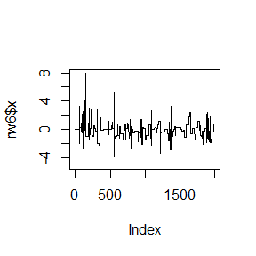

```r
 plot(rw6$x,type="l")
```

```r
print(c(rw1$k, rw2$k, rw3$k, rw4$k,rw5$k,rw6$k))
```

```
## [1] 0.0205 0.1720 0.3130 0.4790 0.6995 0.9130
```

### Question

Implement a Gibbs sampler to generate a bivariate normal chain (Xt, Yt) with zero means, unit standard deviations, and correlation 0.9. Plot the generated sample after discarding a suitable burn-in sample. Fit a simple linear regression model Y = β0 + β1X to the sample and check the residuals of the model for normality and constant variance

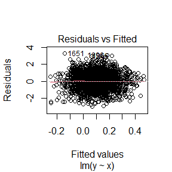

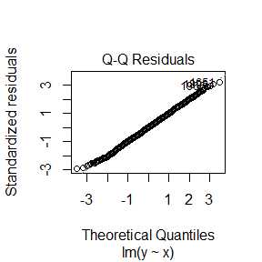

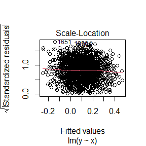

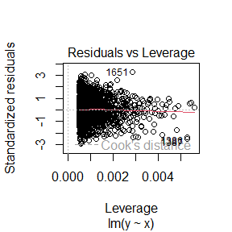

```r
 N<-2000


   x<-y <- numeric(N)
   x[1]<-y[1] <-0
   u <- runif(N)
   k <- 0
   for (i in 2:N) {
     x0<- rnorm(1,0.9*y[i-1],sqrt(0.19))
     y0 <- rnorm(1,0.9*x[i-1], sqrt(0.19))

     x[i] <- x0
     y[i] <- y0

   }

 li<- lm(y~x)
 plot(li)
```

From the plot, we can judge that the residuals are normal and variance-constant.

### Question Refer to Example 9.1. Use the Gelman-Rubin method to monitor convergence of the chain, and run the chain until the chain has converged approximately to the target distribution according to R < ˆ 1.2. (See Exercise 9.9.) Also use the coda [212] package to check for convergence of the chain by the Gelman-Rubin method. Hints: See the help topics for the coda functions gelman.diag, gelman.plot, as.mcmc, and mcmc.list.

```r
set.seed(20231112)
## 函数
Gelman.Rubin <- function(psi) {
# psi[i,j] is the statistic psi(X[i,1:j])
# for chain in i-th row of X
psi <- as.matrix(psi)
n <- ncol(psi)
k <- nrow(psi)
psi.means <- rowMeans(psi) #row means
B <- n * var(psi.means) #between variance est.
psi.w <- apply(psi, 1, "var") #within variances
W <- mean(psi.w) #within est.
v.hat <- W*(n-1)/n + (B/n) #upper variance est.
r.hat <- v.hat / W #G-R statistic
return(r.hat)
}
f <- function(x, sigma) {
if (any(x < 0)) return (0)
stopifnot(sigma > 0)
return((x / sigma^2) * exp(-x^2 / (2*sigma^2)))
}
Rai.chain<-function(sigma, m, x1) {
sigma <- 4
x <- numeric(m)
x[1] <- rchisq(1, df=1)
k <- 0
u <- runif(m)
for (i in 2:m) {
xt <- x[i-1]
y <- rchisq(1, df = xt)
num <- f(y, sigma) * dchisq(xt, df = y)
den <- f(xt, sigma) * dchisq(y, df = xt)
if (u[i] <= num/den) x[i] <- y else {
x[i] <- xt
k <- k+1 #y is rejected
}
}
x
}
sigma <- .2 #parameter of proposal distribution
k <- 4 #number of chains to generate
n <- 20000#length of chains
b <- 10000 #burn-in length
#choose overdispersed initial values
x0 <- c(-10, -5,5, 10)
#generate the chains
X <- matrix(0, nrow=k, ncol=n)
for (i in 1:k)
X[i, ] <- Rai.chain(sigma, n, x0[i])
#compute diagnostic statistics
psi <- t(apply(X, 1, cumsum))
for (i in 1:nrow(psi))
psi[i,] <- psi[i,] / (1:ncol(psi))
print(Gelman.Rubin(psi))
```

```
## [1] 1.087344
```

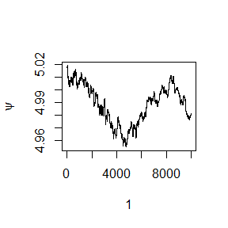

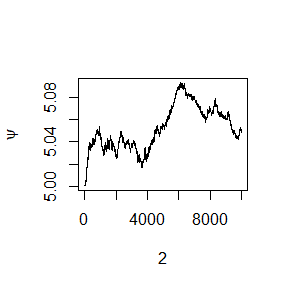

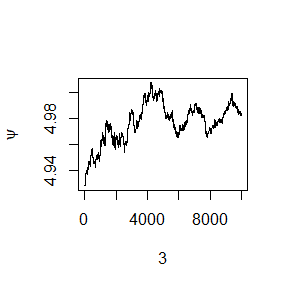

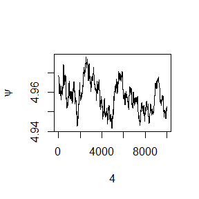

```r
#plot psi for the four chains
for (i in 1:k)
plot(psi[i, (b+1):n], type="l",
xlab=i, ylab=bquote(psi))
```

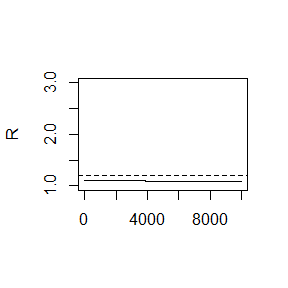

```r
par(mfrow=c(1,1)) #restore default
#plot the sequence of R-hat statistics
rhat <- rep(0, n)
for (j in (b+1):n)
rhat[j] <- Gelman.Rubin(psi[,1:j])
plot(rhat[(b+1):n], type="l", xlab="", ylab="R",ylim=c(1,3))
abline(h=1.2, lty=2)
```

## hw8

### Question In the Morra game, the set of optimal strategies are not changed if a constant is subtracted from every entry of the payoff matrix, or a positive constant is multiplied times every entry of the payoff matrix. However, the simplex algorithm may terminate at a different basic feasible point (also optimal). Compute B <- A + 2, find the solution of game B, and verify that it is one of the extreme points (11.12)–(11.15) of the original game A. Also find the value of game A and game B.

```r
library(boot)
#enter the payoff matrix
A <- matrix(c( 0,-2,-2,3,0,0,4,0,0,
2,0,0,0,-3,-3,4,0,0,
2,0,0,3,0,0,0,-4,-4,
-3,0,-3,0,4,0,0,5,0,
0,3,0,-4,0,-4,0,5,0,
0,3,0,0,4,0,-5,0,-5,
-4,-4,0,0,0,5,0,0,6,
0,0,4,-5,-5,0,0,0,6,
0,0,4,0,0,5,-6,-6,0), 9, 9)
B<- A+2
solve.game <- function(A) {
#solve the two player zero-sum game by simplex method
#optimize for player 1, then player 2
#maximize v subject to ...
#let x strategies 1:m, and put v as extra variable
#A1, the <= constraints
#
min.A <- min(A)
A <- A - min.A #so that v >= 0
max.A <- max(A)
A <- A / max(A)
m <- nrow(A)
n <- ncol(A)
it <- n^3
a <- c(rep(0, m), 1) #objective function
A1 <- -cbind(t(A), rep(-1, n)) #constraints <=
b1 <- rep(0, n)
A3 <- t(as.matrix(c(rep(1, m), 0))) #constraints sum(x)=1
b3 <- 1
sx <- simplex(a=a, A1=A1, b1=b1, A3=A3, b3=b3,
maxi=TRUE, n.iter=it)
#the ’solution’ is [x1,x2,...,xm | value of game]
#
#minimize v subject to ...
#let y strategies 1:n, with v as extra variable
a <- c(rep(0, n), 1) #objective function
A1 <- cbind(A, rep(-1, m)) #constraints <=
b1 <- rep(0, m)
A3 <- t(as.matrix(c(rep(1, n), 0))) #constraints sum(y)=1
b3 <- 1
sy <- simplex(a=a, A1=A1, b1=b1, A3=A3, b3=b3,
maxi=FALSE, n.iter=it)
soln <- list("A" = A * max.A + min.A,
"x" = sx$soln[1:m],
"y" = sy$soln[1:n],
"v" = sx$soln[m+1] * max.A + min.A)
soln
}
sB <- solve.game(B)
round(cbind(sB$x, sB$y), 7)
```

```
##         [,1]      [,2]
## x1 0.0000000 0.0000000
## x2 0.0000000 0.0000000
## x3 0.4098361 0.4098361
## x4 0.0000000 0.0000000
## x5 0.3278689 0.3278689
## x6 0.0000000 0.0000000
## x7 0.2622951 0.2622951
## x8 0.0000000 0.0000000
## x9 0.0000000 0.0000000
```

```r
C<- A+B
sC <- solve.game(C)
round(cbind(sC$x, sC$y), 7)
```

```
##         [,1]      [,2]
## x1 0.0000000 0.0000000
## x2 0.0000000 0.0000000
## x3 0.4098361 0.4098361
## x4 0.0000000 0.0000000
## x5 0.3278689 0.3278689
## x6 0.0000000 0.0000000
## x7 0.2622951 0.2622951
## x8 0.0000000 0.0000000
## x9 0.0000000 0.0000000
```

## hw9

### Question 2

```r
library(microbenchmark)
library(Rcpp)
 gibbs_r <- function(N, thin , n,a,b) {
    mat <- matrix(nrow = N, ncol = 2)
    x <- y <- 0
    for (i in 1:N) {
      for (j in 1:thin) {
        x <- rbinom(1, n, y)
        y <- rbeta(1,x+a,n-x+b)
      }
      mat[i, ] <- c(x, y)
    }
    mat
 }
 dir_cpp <- 'C:/Users/11146/Desktop/studying/Rlab/statcomp/hw9/'
 sourceCpp(paste0(dir_cpp,"gibbsC.cpp"))
 ts <- microbenchmark(
 gibbs_r(100, 10 , 10 , 5,5),
 gibbs_cpp(100, 10 , 10,5,5)
 )
 summary(ts)
```

```
##                           expr    min      lq     mean  median      uq     max
## 1   gibbs_r(100, 10, 10, 5, 5) 3155.4 3375.75 4177.689 3614.45 4111.05 11110.2
## 2 gibbs_cpp(100, 10, 10, 5, 5)  350.8  359.95  404.286  368.00  383.15  1460.7
##   neval
## 1   100
## 2   100
```